# Part I - Environmental & Social Factors of Industrialization from 1990-2019.

## Introduction

I'm working with a dataset that I created from combining several smaller ones to examine the growth and industrialization of countries, essentially. I started out just looking at CO2 emissions, but needed to expand my dataset significantly in order to fulfill the variable requirements of this project, so I looked for other datasets that reflected factors of economic development, and so my combined dataset will incorporate the following (datasets will be specifically referenced and linked at the bottom of the notebook):

1. CO2 Emissions (Source: Kaggle via World Bank)
2. Child Mortality; 0-5 Year Olds Dying per 1000 Born (Source: Gapminder)
3. Income Per Person/GDP Per Capita; Inflation-Adjusted (Source: Gapminder)
4. Life Expectancy in Years (Source: Gapminder)
5. Population Density per Square Km (Source: Gapminder)

## Preliminary Wrangling

I did most of the data cleaning in Excel due to the small size of the source datasets (around 200 rows each before the required melts). I standardized numerical formats (some had for example 31k instead of 31000) and trimmed the data to the same range of years and the same countries. Here I will be performing melts, renaming a few things, and combining them into a final single dataframe.

```python
# import all packages and set plots to be embedded inline
import numpy as np
import pandas as pd
import matplotlib.pyplot as plt
import seaborn as sns

%matplotlib inline
sns.set(rc = {'figure.figsize':(25,8)})
```

#### Dataset 1: CO2 Emissions

```python
co2_orig = pd.read_csv('CO2_emissions.csv')
co2_orig.head(3)
```

|  | Country Name | country_code | Region | Indicator Name | 1990 | 1991 | 1992 | 1993 | 1994 | 1995 | ... | 2011 | 2012 | 2013 | 2014 | 2015 | 2016 | 2017 | 2018 | 2019 | 2019.1 |
| --- | --- | --- | --- | --- | --- | --- | --- | --- | --- | --- | --- | --- | --- | --- | --- | --- | --- | --- | --- | --- | --- |
| 0 | Afghanistan | AFG | South Asia | CO2 emissions (metric tons per capita) | 0.191745 | 0.167682 | 0.095958 | 0.084721 | 0.075546 | 0.068468 | ... | 0.296506 | 0.259295 | 0.185624 | 0.146236 | 0.172897 | 0.149789 | 0.131695 | 0.163295 | 0.159824 | 0.159824 |
| 1 | Angola | AGO | Sub-Saharan Africa | CO2 emissions (metric tons per capita) | 0.553662 | 0.544539 | 0.543557 | 0.708984 | 0.836804 | 0.912141 | ... | 0.985522 | 0.950696 | 1.036294 | 1.099779 | 1.135044 | 1.031811 | 0.813301 | 0.777675 | 0.792137 | 0.792137 |
| 2 | Albania | ALB | Europe & Central Asia | CO2 emissions (metric tons per capita) | 1.819542 | 1.242810 | 0.683700 | 0.638307 | 0.645355 | 0.605436 | ... | 1.669423 | 1.503240 | 1.533630 | 1.668337 | 1.603775 | 1.557664 | 1.788786 | 1.782739 | 1.692248 | 1.692248 |

3 rows × 35 columns

Here I'm just going to drop the Indicator Name column and there is also a duplicated 2019.1 column that I'll drop, and then perform a melt to turn all the years into one "year" column. I'm also going to rename a couple of the columns.

```python
co2_orig.rename(columns = {'Country Name' : 'country_name'}, inplace = True)
co2_orig.rename(columns = {'Region' : 'region'}, inplace = True)

co2_orig.drop(columns = ['Indicator Name'], axis = 1, inplace = True)
co2_orig.drop(columns = ['2019.1'], axis = 1, inplace = True)
```

```python
co2_orig.head(3)
```

|  | country_name | country_code | region | 1990 | 1991 | 1992 | 1993 | 1994 | 1995 | 1996 | ... | 2010 | 2011 | 2012 | 2013 | 2014 | 2015 | 2016 | 2017 | 2018 | 2019 |
| --- | --- | --- | --- | --- | --- | --- | --- | --- | --- | --- | --- | --- | --- | --- | --- | --- | --- | --- | --- | --- | --- |
| 0 | Afghanistan | AFG | South Asia | 0.191745 | 0.167682 | 0.095958 | 0.084721 | 0.075546 | 0.068468 | 0.062588 | ... | 0.243614 | 0.296506 | 0.259295 | 0.185624 | 0.146236 | 0.172897 | 0.149789 | 0.131695 | 0.163295 | 0.159824 |
| 1 | Angola | AGO | Sub-Saharan Africa | 0.553662 | 0.544539 | 0.543557 | 0.708984 | 0.836804 | 0.912141 | 1.072168 | ... | 0.976184 | 0.985522 | 0.950696 | 1.036294 | 1.099779 | 1.135044 | 1.031811 | 0.813301 | 0.777675 | 0.792137 |
| 2 | Albania | ALB | Europe & Central Asia | 1.819542 | 1.242810 | 0.683700 | 0.638307 | 0.645355 | 0.605436 | 0.612367 | ... | 1.527624 | 1.669423 | 1.503240 | 1.533630 | 1.668337 | 1.603775 | 1.557664 | 1.788786 | 1.782739 | 1.692248 |

3 rows × 33 columns

```python
co2_melted = co2_orig.melt(id_vars = ['country_name', 'region'], value_vars=['1990', '1991', '1992', '1993', '1994', '1995', '1996', '1997', '1998', '1999', '2000', '2001', '2002', '2003', '2004', '2005', '2006', '2007', '2008', '2009', '2010', '2011', '2012', '2013', '2014', '2015', '2016', '2017', '2018', '2019'], var_name = 'year', value_name = 'emissions_per_cap')
co2_melted.head(5)
```

|  | country_name | region | year | emissions_per_cap |
| --- | --- | --- | --- | --- |
| 0 | Afghanistan | South Asia | 1990 | 0.191745 |
| 1 | Angola | Sub-Saharan Africa | 1990 | 0.553662 |
| 2 | Albania | Europe & Central Asia | 1990 | 1.819542 |
| 3 | United Arab Emirates | Middle East & North Africa | 1990 | 30.195189 |
| 4 | Argentina | Latin America & Caribbean | 1990 | 3.075541 |

```python
#co2_orig.isnull().sum()

#no null values
```

```python
co2_melted.duplicated().sum()
```

```
0
```

```python
co2_melted.info()
```

```
<class 'pandas.core.frame.DataFrame'>
RangeIndex: 5460 entries, 0 to 5459
Data columns (total 4 columns):
 #   Column             Non-Null Count  Dtype
---  ------             --------------  -----
 0   country_name       5460 non-null   object
 1   region             5460 non-null   object
 2   year               5460 non-null   object
 3   emissions_per_cap  5460 non-null   float64
dtypes: float64(1), object(3)
memory usage: 170.8+ KB
```

#### Dataset 2: Child Mortality

```python
child_mortality_orig = pd.read_csv('gapminder_child_mortality_0_5_year_olds_dying_per_1000_born.csv')
child_mortality_orig.head()
```

|  | country | 1990 | 1991 | 1992 | 1993 | 1994 | 1995 | 1996 | 1997 | 1998 | ... | 2010 | 2011 | 2012 | 2013 | 2014 | 2015 | 2016 | 2017 | 2018 | 2019 |
| --- | --- | --- | --- | --- | --- | --- | --- | --- | --- | --- | --- | --- | --- | --- | --- | --- | --- | --- | --- | --- | --- |
| 0 | Afghanistan | 173.0 | 167.0 | 161.0 | 156.0 | 151.0 | 146.0 | 142.0 | 138.0 | 133.0 | ... | 84.10 | 80.50 | 77.0 | 73.50 | 70.40 | 67.50 | 64.70 | 62.30 | 60.10 | 58.10 |
| 1 | Angola | 224.0 | 224.0 | 224.0 | 224.0 | 223.0 | 221.0 | 219.0 | 215.0 | 211.0 | ... | 113.00 | 105.00 | 98.4 | 92.90 | 88.10 | 84.00 | 80.40 | 77.20 | 74.50 | 72.30 |
| 2 | Albania | 38.9 | 37.4 | 35.9 | 34.5 | 33.2 | 31.7 | 30.3 | 28.8 | 27.4 | ... | 12.30 | 11.40 | 10.7 | 10.10 | 9.60 | 9.27 | 9.02 | 8.82 | 8.68 | 8.52 |
| 3 | United Arab Emirates | 15.7 | 15.0 | 14.3 | 13.7 | 13.2 | 12.7 | 12.3 | 11.9 | 11.5 | ... | 8.28 | 8.13 | 8.0 | 7.91 | 7.83 | 7.76 | 7.68 | 7.59 | 7.37 | 7.16 |
| 4 | Argentina | 28.1 | 27.3 | 26.3 | 25.2 | 24.1 | 23.1 | 22.1 | 21.2 | 20.4 | ... | 13.90 | 13.30 | 12.7 | 12.10 | 11.50 | 10.90 | 10.40 | 9.94 | 9.66 | 9.40 |

5 rows × 31 columns

For this I'll just change the name of the "country" column to match, then do the melt. I'm going to repeat this process for each df and to make things easier I'm going to merge them as I go.

```python
child_mortality_orig.rename(columns = {'country' : 'country_name'}, inplace = True)
```

```python
child_mortality_melted = child_mortality_orig.melt(id_vars = ['country_name'], value_vars=['1990', '1991', '1992', '1993', '1994', '1995', '1996', '1997', '1998', '1999', '2000', '2001', '2002', '2003', '2004', '2005', '2006', '2007', '2008', '2009', '2010', '2011', '2012', '2013', '2014', '2015', '2016', '2017', '2018', '2019'], var_name = 'year', value_name = 'child_mort_rate')
child_mortality_melted.head(5)
```

|  | country_name | year | child_mort_rate |
| --- | --- | --- | --- |
| 0 | Afghanistan | 1990 | 173.0 |
| 1 | Angola | 1990 | 224.0 |
| 2 | Albania | 1990 | 38.9 |
| 3 | United Arab Emirates | 1990 | 15.7 |
| 4 | Argentina | 1990 | 28.1 |

```python
child_mortality_melted.info()
```

```
<class 'pandas.core.frame.DataFrame'>
RangeIndex: 5460 entries, 0 to 5459
Data columns (total 3 columns):
 #   Column           Non-Null Count  Dtype
---  ------           --------------  -----
 0   country_name     5460 non-null   object
 1   year             5460 non-null   object
 2   child_mort_rate  5460 non-null   float64
dtypes: float64(1), object(2)
memory usage: 128.1+ KB
```

```python
#merge the dfs

combined_data = pd.merge(co2_melted, child_mortality_melted, on=['country_name','year'])
```

```python
combined_data.head()
```

|  | country_name | region | year | emissions_per_cap | child_mort_rate |
| --- | --- | --- | --- | --- | --- |
| 0 | Afghanistan | South Asia | 1990 | 0.191745 | 173.0 |
| 1 | Angola | Sub-Saharan Africa | 1990 | 0.553662 | 224.0 |
| 2 | Albania | Europe & Central Asia | 1990 | 1.819542 | 38.9 |
| 3 | United Arab Emirates | Middle East & North Africa | 1990 | 30.195189 | 15.7 |
| 4 | Argentina | Latin America & Caribbean | 1990 | 3.075541 | 28.1 |

```python
combined_data.info()
```

```
<class 'pandas.core.frame.DataFrame'>
Int64Index: 5400 entries, 0 to 5399
Data columns (total 5 columns):
 #   Column             Non-Null Count  Dtype
---  ------             --------------  -----
 0   country_name       5400 non-null   object
 1   region             5400 non-null   object
 2   year               5400 non-null   object
 3   emissions_per_cap  5400 non-null   float64
 4   child_mort_rate    5400 non-null   float64
dtypes: float64(2), object(3)
memory usage: 253.1+ KB
```

#### Dataset 3: Income Per Person

```python
income_pp_orig = pd.read_csv('gapminder_income_per_person_gdppercapita_ppp_inflation_adjusted.csv')
income_pp_orig.head(3)
```

|  | country | 1990 | 1991 | 1992 | 1993 | 1994 | 1995 | 1996 | 1997 | 1998 | ... | 2010 | 2011 | 2012 | 2013 | 2014 | 2015 | 2016 | 2017 | 2018 | 2019 |
| --- | --- | --- | --- | --- | --- | --- | --- | --- | --- | --- | --- | --- | --- | --- | --- | --- | --- | --- | --- | --- | --- |
| 0 | Afghanistan | 1020 | 981 | 672 | 498 | 736 | 698 | 663 | 634 | 603 | ... | 1910 | 2080 | 2120 | 2100 | 2070 | 2060 | 2060 | 2030 | 2070 | 1970 |
| 1 | Angola | 1670 | 1620 | 1260 | 1300 | 1530 | 1780 | 1960 | 2110 | 2210 | ... | 7680 | 8040 | 8140 | 8240 | 8040 | 7570 | 7310 | 6930 | 6670 | 6120 |
| 2 | Albania | 3500 | 3270 | 3600 | 3920 | 4470 | 4910 | 4400 | 4820 | 5480 | ... | 11100 | 11200 | 11400 | 11600 | 11900 | 12300 | 12800 | 13300 | 13700 | 13200 |

3 rows × 31 columns

```python
income_pp_orig.rename(columns = {'country' : 'country_name'}, inplace = True)
```

```python
income_pp_melted = income_pp_orig.melt(id_vars = ['country_name'], value_vars=['1990', '1991', '1992', '1993', '1994', '1995', '1996', '1997', '1998', '1999', '2000', '2001', '2002', '2003', '2004', '2005', '2006', '2007', '2008', '2009', '2010', '2011', '2012', '2013', '2014', '2015', '2016', '2017', '2018', '2019'], var_name = 'year', value_name = 'income_per_person')
income_pp_melted.head(5)
```

|  | country_name | year | income_per_person |
| --- | --- | --- | --- |
| 0 | Afghanistan | 1990 | 1020 |
| 1 | Angola | 1990 | 1670 |
| 2 | Albania | 1990 | 3500 |
| 3 | United Arab Emirates | 1990 | 50500 |
| 4 | Argentina | 1990 | 15200 |

```python
#merge
combined_data2 = pd.merge(combined_data, income_pp_melted, on=['country_name','year'])
```

```python
combined_data2.head()
```

|  | country_name | region | year | emissions_per_cap | child_mort_rate | income_per_person |
| --- | --- | --- | --- | --- | --- | --- |
| 0 | Afghanistan | South Asia | 1990 | 0.191745 | 173.0 | 1020 |
| 1 | Angola | Sub-Saharan Africa | 1990 | 0.553662 | 224.0 | 1670 |
| 2 | Albania | Europe & Central Asia | 1990 | 1.819542 | 38.9 | 3500 |
| 3 | United Arab Emirates | Middle East & North Africa | 1990 | 30.195189 | 15.7 | 50500 |
| 4 | Argentina | Latin America & Caribbean | 1990 | 3.075541 | 28.1 | 15200 |

```python
combined_data2.info()
```

```
<class 'pandas.core.frame.DataFrame'>
Int64Index: 5400 entries, 0 to 5399
Data columns (total 6 columns):
 #   Column             Non-Null Count  Dtype
---  ------             --------------  -----
 0   country_name       5400 non-null   object
 1   region             5400 non-null   object
 2   year               5400 non-null   object
 3   emissions_per_cap  5400 non-null   float64
 4   child_mort_rate    5400 non-null   float64
 5   income_per_person  5400 non-null   int64
dtypes: float64(2), int64(1), object(3)
memory usage: 295.3+ KB
```

#### Dataset 4: Life Expectancy

```python
life_expectancy_orig = pd.read_csv('gapminder_life_expectancy_years.csv')
life_expectancy_orig.head(3)
```

|  | country | 1990 | 1991 | 1992 | 1993 | 1994 | 1995 | 1996 | 1997 | 1998 | ... | 2010 | 2011 | 2012 | 2013 | 2014 | 2015 | 2016 | 2017 | 2018 | 2019 |
| --- | --- | --- | --- | --- | --- | --- | --- | --- | --- | --- | --- | --- | --- | --- | --- | --- | --- | --- | --- | --- | --- |
| 0 | Afghanistan | 53.8 | 54.2 | 54.4 | 53.9 | 54.3 | 54.7 | 54.5 | 53.3 | 54.7 | ... | 61.0 | 61.4 | 61.9 | 61.9 | 61.9 | 62.0 | 62.9 | 62.7 | 63.3 | 63.4 |
| 1 | Angola | 50.3 | 50.3 | 49.0 | 50.3 | 51.2 | 51.7 | 51.6 | 50.6 | 51.9 | ... | 60.8 | 61.4 | 62.1 | 63.0 | 63.5 | 63.9 | 64.2 | 64.6 | 65.1 | 65.2 |
| 2 | Albania | 72.6 | 73.2 | 73.8 | 74.6 | 74.6 | 74.5 | 72.9 | 74.8 | 75.1 | ... | 78.1 | 78.2 | 78.3 | 78.2 | 78.1 | 78.2 | 78.3 | 78.4 | 78.5 | 77.9 |

3 rows × 31 columns

```python
life_expectancy_orig.rename(columns = {'country' : 'country_name'}, inplace = True)
```

```python
life_expectancy_melted = life_expectancy_orig.melt(id_vars = ['country_name'], value_vars=['1990', '1991', '1992', '1993', '1994', '1995', '1996', '1997', '1998', '1999', '2000', '2001', '2002', '2003', '2004', '2005', '2006', '2007', '2008', '2009', '2010', '2011', '2012', '2013', '2014', '2015', '2016', '2017', '2018', '2019'], var_name = 'year', value_name = 'life_expectancy')
life_expectancy_melted.head(5)
```

|  | country_name | year | life_expectancy |
| --- | --- | --- | --- |
| 0 | Afghanistan | 1990 | 53.8 |
| 1 | Angola | 1990 | 50.3 |
| 2 | Albania | 1990 | 72.6 |
| 3 | United Arab Emirates | 1990 | 68.7 |
| 4 | Argentina | 1990 | 72.7 |

```python
#merge
combined_data3 = pd.merge(combined_data2, life_expectancy_melted, on=['country_name','year'])
```

```python
combined_data3.head()
```

|  | country_name | region | year | emissions_per_cap | child_mort_rate | income_per_person | life_expectancy |
| --- | --- | --- | --- | --- | --- | --- | --- |
| 0 | Afghanistan | South Asia | 1990 | 0.191745 | 173.0 | 1020 | 53.8 |
| 1 | Angola | Sub-Saharan Africa | 1990 | 0.553662 | 224.0 | 1670 | 50.3 |
| 2 | Albania | Europe & Central Asia | 1990 | 1.819542 | 38.9 | 3500 | 72.6 |
| 3 | United Arab Emirates | Middle East & North Africa | 1990 | 30.195189 | 15.7 | 50500 | 68.7 |
| 4 | Argentina | Latin America & Caribbean | 1990 | 3.075541 | 28.1 | 15200 | 72.7 |

```python
combined_data3.info()
```

```
<class 'pandas.core.frame.DataFrame'>
Int64Index: 5400 entries, 0 to 5399
Data columns (total 7 columns):
 #   Column             Non-Null Count  Dtype
---  ------             --------------  -----
 0   country_name       5400 non-null   object
 1   region             5400 non-null   object
 2   year               5400 non-null   object
 3   emissions_per_cap  5400 non-null   float64
 4   child_mort_rate    5400 non-null   float64
 5   income_per_person  5400 non-null   int64
 6   life_expectancy    5400 non-null   float64
dtypes: float64(3), int64(1), object(3)
memory usage: 337.5+ KB
```

#### Dataset 5: Population Density

```python
pop_density_orig = pd.read_csv('gapminder_population_density_per_square_km.csv')
pop_density_orig.head(3)
```

|  | country | 1990 | 1991 | 1992 | 1993 | 1994 | 1995 | 1996 | 1997 | 1998 | ... | 2010 | 2011 | 2012 | 2013 | 2014 | 2015 | 2016 | 2017 | 2018 | 2019 |
| --- | --- | --- | --- | --- | --- | --- | --- | --- | --- | --- | --- | --- | --- | --- | --- | --- | --- | --- | --- | --- | --- |
| 0 | Afghanistan | 20.40 | 22.2 | 24.2 | 26.2 | 27.7 | 28.9 | 29.6 | 30.2 | 30.9 | ... | 46.1 | 47.7 | 49.4 | 51.1 | 52.7 | 54.2 | 55.6 | 56.9 | 58.3 | 59.6 |
| 1 | Angola | 9.83 | 10.2 | 10.5 | 10.8 | 11.2 | 11.6 | 11.9 | 12.3 | 12.7 | ... | 19.4 | 20.1 | 20.9 | 21.6 | 22.4 | 23.1 | 23.9 | 24.7 | 25.5 | 26.4 |
| 2 | Albania | 120.00 | 118.0 | 117.0 | 115.0 | 114.0 | 113.0 | 113.0 | 114.0 | 114.0 | ... | 107.0 | 106.0 | 106.0 | 106.0 | 105.0 | 105.0 | 105.0 | 105.0 | 105.0 | 105.0 |

3 rows × 31 columns

```python
pop_density_orig.rename(columns = {'country' : 'country_name'}, inplace = True)
```

```python
pop_density_melted = pop_density_orig.melt(id_vars = ['country_name'], value_vars=['1990', '1991', '1992', '1993', '1994', '1995', '1996', '1997', '1998', '1999', '2000', '2001', '2002', '2003', '2004', '2005', '2006', '2007', '2008', '2009', '2010', '2011', '2012', '2013', '2014', '2015', '2016', '2017', '2018', '2019'], var_name = 'year', value_name = 'population_density')
pop_density_melted.head(5)
```

|  | country_name | year | population_density |
| --- | --- | --- | --- |
| 0 | Afghanistan | 1990 | 20.40 |
| 1 | Angola | 1990 | 9.83 |
| 2 | Albania | 1990 | 120.00 |
| 3 | United Arab Emirates | 1990 | 23.20 |
| 4 | Argentina | 1990 | 12.10 |

```python
#merge
combined_data4 = pd.merge(combined_data3, pop_density_melted, on=['country_name','year'])
```

```python
combined_data4.head()
```

|  | country_name | region | year | emissions_per_cap | child_mort_rate | income_per_person | life_expectancy | population_density |
| --- | --- | --- | --- | --- | --- | --- | --- | --- |
| 0 | Afghanistan | South Asia | 1990 | 0.191745 | 173.0 | 1020 | 53.8 | 20.40 |
| 1 | Angola | Sub-Saharan Africa | 1990 | 0.553662 | 224.0 | 1670 | 50.3 | 9.83 |
| 2 | Albania | Europe & Central Asia | 1990 | 1.819542 | 38.9 | 3500 | 72.6 | 120.00 |
| 3 | United Arab Emirates | Middle East & North Africa | 1990 | 30.195189 | 15.7 | 50500 | 68.7 | 23.20 |
| 4 | Argentina | Latin America & Caribbean | 1990 | 3.075541 | 28.1 | 15200 | 72.7 | 12.10 |

```python
combined_data4.info()
```

```
<class 'pandas.core.frame.DataFrame'>
Int64Index: 5400 entries, 0 to 5399
Data columns (total 8 columns):
 #   Column              Non-Null Count  Dtype
---  ------              --------------  -----
 0   country_name        5400 non-null   object
 1   region              5400 non-null   object
 2   year                5400 non-null   object
 3   emissions_per_cap   5400 non-null   float64
 4   child_mort_rate     5400 non-null   float64
 5   income_per_person   5400 non-null   int64
 6   life_expectancy     5400 non-null   float64
 7   population_density  5400 non-null   float64
dtypes: float64(4), int64(1), object(3)
memory usage: 379.7+ KB
```

```python
combined_data4.country_name.nunique()
```

```
180
```

```python
industrialization_data = combined_data4.copy()
industrialization_data.to_csv(r'industrialization_data.csv')
```

### What is the structure of your dataset?

The end result of all that merging is a dataframe with 8 columns and 5400 rows. There are 180 countries represented in this dataset, which is nearly all of the countries in the world. Most of the ones removed were either territories (i.e. Macao, Puerto Rico) or extremely small island nations (i.e. Vanuatu) that didn't have any data. The 2 categorical variables are country name and region, there's year (not sure how you'd classify that), and then the remaining 5 are quantitative variables for emissions per capita, child mortality rate, income rate, life expectancy and population density.

### What is/are the main feature(s) of interest in your dataset?

These are all variables that I think could have some level of interaction. My initial desire was to look at emission rates globally, but now we can look at how for example child mortality rates and life expectancy correlate with emission rates; in developing countries, an increase in emissions often indicates an increase in industrialization and therefore an overall increase in wealth, which should result in lower infant mortality and higher life expectancy, but pollution adversely affects both. As a lifelong urbanite I'm also curious to see how population density relates to these other variables.

### What features in the dataset do you think will help support your investigation into your feature(s) of interest?

I'm not really sure what this question means. I imagine that the numeric values will speak for themselves and by doing some visualizations it will be pretty clear. I do expect to see positive correlations between emissions and things like income, population density etc but there may be some surprises when it comes to the strength of the correlation in many of these cases.

## Univariate Exploration

Here I'm mostly going to do some bar charts for each quantitative variable across the different regions. Emissions provides a good opportunity for a nice colorful pie chart.

```python
industrialization_data.head(2)
```

|  | country_name | region | year | emissions_per_cap | child_mort_rate | income_per_person | life_expectancy | population_density |
| --- | --- | --- | --- | --- | --- | --- | --- | --- |
| 0 | Afghanistan | South Asia | 1990 | 0.191745 | 173.0 | 1020 | 53.8 | 20.40 |
| 1 | Angola | Sub-Saharan Africa | 1990 | 0.553662 | 224.0 | 1670 | 50.3 | 9.83 |

The first thing I want to do since it was my initial subject of interest, is look specifically at emissions and see how the various regions compare. The plot I would be inclined to do first is bivariate so I've had to stick it at the front of the next section. Here I can do some pie charts though to see the proportions of emissions each region is responsible for. Let's first look at the emissions in 1990, and then in 2019.

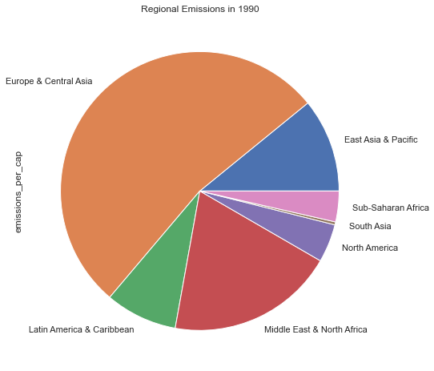

```python
emissions = industrialization_data[['country_name', 'region', 'year', 'emissions_per_cap']]
nineties_emissions = emissions.loc[emissions['year'] == '1990']
nineties_emissions.groupby(['region']).sum().plot(kind='pie', y= 'emissions_per_cap', legend = None)
plt.title('Regional Emissions in 1990');
```

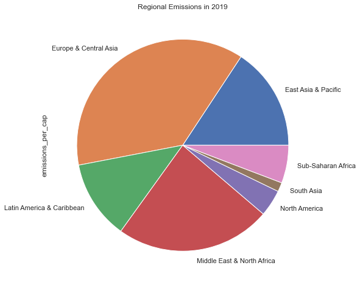

```python
nineties_emissions = emissions.loc[emissions['year'] == '2019']
nineties_emissions.groupby(['region']).sum().plot(kind='pie', y= 'emissions_per_cap', legend = None)
plt.title('Regional Emissions in 2019');
```

The change we see across these are interesting. There is a marked decrease in Europe & Central Asia, which tracks with some foreign policy decisions in Europe in the 2000s around nuclear energy and other renewables, as well as a significant increase in LATAM, Sub-Sararan Africa and South Asia. As I mentioned as countries industrialize more they have a higher higher consumption of fossil fuels and therefore more carbon emissions. This is surely the case in LATAM, and India emerging in the past decade or so could account for the increase in South Asia.

Next I'd like to look at how the other variables (child mortality, income, life expectancy, population density) looked in 1990, and then in the bivariate section I'll do some clustered charts to see how they compare between the start and end of the dataset. Honestly having to segment this into categories of variate-ness is a little disorienting in terms of presenting a narrative.

```python
#function for bar charts to reduce repetitive code

def unibar(plotdata, ydata, x_label, y_label, plot_title):
    plotdata.groupby(['region']).mean().plot(kind='bar', y= ydata, legend = None)
    plt.title(plot_title, fontsize = 17)
    plt.xlabel(x_label, fontsize = 17)
    plt.ylabel(y_label, fontsize = 17)
    plt.xticks(rotation = 45);
```

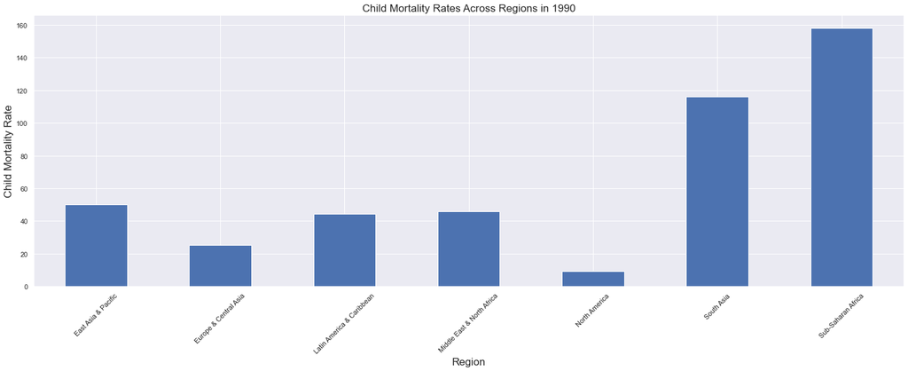

```python
#child mortality
nineties = industrialization_data.loc[industrialization_data['year'] == '1990']
child_mort_nineties = nineties[['region', 'child_mort_rate']]

unibar(child_mort_nineties, 'child_mort_rate', 'Region', 'Child Mortality Rate', 'Child Mortality Rates Across Regions in 1990')
```

This is actually pretty stunning. It makes sense that The US and Canada have comparatively low child mortality rates in 1990, as so many countries have developed significantly since then, but the high child mortality rates in South Asia and Sub Saharan Africa are breathtaking. Let's look at life expectancy and see how that compares.

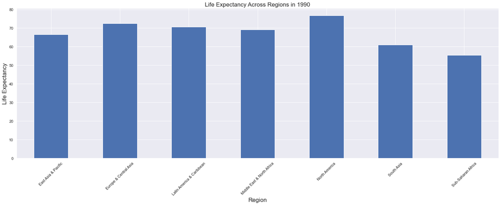

```python
#life expectancy
nineties_life = nineties[['region', 'life_expectancy']]

unibar(nineties_life, 'life_expectancy', 'Region', 'Life Expectancy', 'Life Expectancy Across Regions in 1990')
```

Here I plotted the mean life expectancy for each region. We still see North America as coming out on top, and there's a difference of around 20 years between North America and Sub Saharan Africa, which is significant, and South Asia is not much better. Keep in mind that life expectancy data is usually affected by child mortality rates. Consider the trope that adults in the Middle Ages only lived to be 40ish - that's not true, if they reached adulthood they usually lived to their 70s or later like everyone else. The numbers were skewed by an extraordinary infant mortality rate due to lack of medical care/knowledge and sanitation, among other things.

Next we'll look at GDP per person.

[figure not shown]

```python
#GDP per capita
nineties_income = nineties[['region', 'income_per_person']]

unibar(nineties_income, 'income_per_person', 'Region', 'Life Expectancy', 'GDP per Capita Across Regions in 1990')
```

To me the main surprise here is the disparity between Europe and North America, but Europe's mean may be brought down a bit by Central Asia, and in 1990 right at the very end of the USSR a lot of Eastern Europe was very impoverished and in social disarray. The Middle East being nearly on par (comparatively) with Europe is also a bit surprising but I assume that has to do with oil-producing nations being located there.

The last one we'll look at here is population density. I'm more interested in that as a variable to compare to others rather than as a standalone, but since we're introducing variables here we might as well look at it.

[figure not shown]

```python
#life expectancy
nineties_pop = nineties[['region', 'population_density']]

unibar(nineties_pop, 'population_density', 'Region', 'Life Expectancy', 'Avg Population Density Across Regions in 1990')
```

This is a little surprising but I think it's because of the categories used in these datasets. South Asia and East Asia make sense (China and India are enormous countries that currently make up over 35% of the global population) but I think it's interesting that the Middle East and North Africa are so high above North America. This may be due to the fact that North Africa has some really populous countries (Algeria, Sudan, Egypt) and the North American category only contains two countries, one of whom (Canada) is mostly uninhabitable due to being mostly in the arctic circle, and the US's most populous city, New York, is smaller than your average city in China. Fun fact: 90% of Canada is uninhabited and in 2022 the entire national population is about the same as the population of California. So in terms of number of people packed into spaces, due to how this data is segmented, this makes sense.

### Discuss the distribution(s) of your variable(s) of interest. Were there any unusual points? Did you need to perform any transformations?

I did not need to perform any transformations. The distributions all made sense upon considering them, although the visualizations did produce some results that surprised me upon first seeing them, which I outlined below the individual charts. I do think some of the surprises (like North America's low placement with population distribution) is due to how the data is segmented, as I mentioned. But in general, when placed in the context of regional development in 1990 (and in the case of the pie charts, development over time) the distributions are logical.

### Of the features you investigated, were there any unusual distributions? Did you perform any operations on the data to tidy, adjust, or change the form of the data? If so, why did you do this?

The only thing that gave me pause was that the category of North America only included two countries. In reality it also includes Mexico, the Caribbean, and Central America, and the exclusion of Mexico in particular, a large and populous country with a diverse and successful manufacturing industry, impacts North America's data obviously. However I chose to leave it is it is because the data had been segmented to separate out the Caribbean and Latin America (which obviously includes Mexico and Central America), and when considering indeces of development, it makes a lot of sense to do that, as these regions have a lot of cultural and political commonalities or relationships that impact development and are deeper than the sort of arbitrary designation of "North America." So I left that, and nothing else required change or tidying.

## Bivariate Exploration

Here I'm going to primarily do line charts to look at progression over time, and some scatter plots.

```python
industrialization_data.head(2)
```

|  | country_name | region | year | emissions_per_cap | child_mort_rate | income_per_person | life_expectancy | population_density |
| --- | --- | --- | --- | --- | --- | --- | --- | --- |
| 0 | Afghanistan | South Asia | 1990 | 0.191745 | 173.0 | 1020 | 53.8 | 20.40 |
| 1 | Angola | Sub-Saharan Africa | 1990 | 0.553662 | 224.0 | 1670 | 50.3 | 9.83 |

Here I'll do the plot I would have preferred to do right at the outset - look at emissions regionally over time all at once. As someone who follows climate change news pretty closely I'm generally aware that the US and China are among the world's most prolific polluters, though it's worth noting that here the emissions refer specifically to carbon dioxide, which is not the only greenhouse gas. Sulfur dioxide and methane are also huge issues.

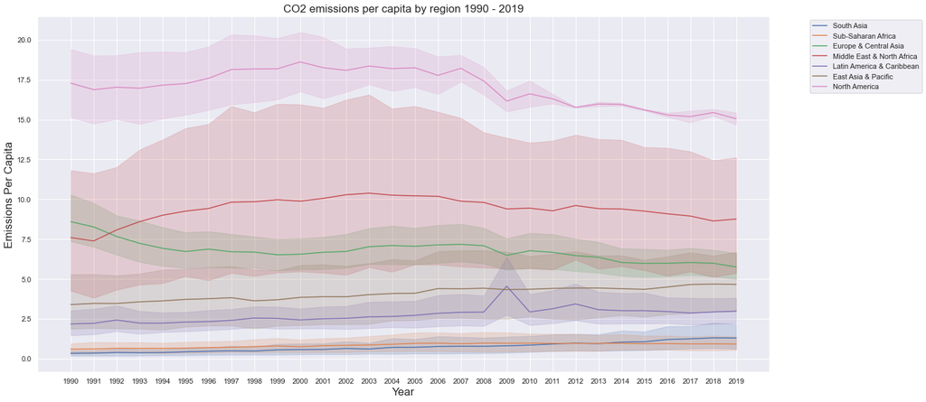

```python
plt.figure(figsize=(20,10))
sns.lineplot(x = 'year', y = 'emissions_per_cap', data=industrialization_data, hue='region')
plt.xlabel('Year', fontsize = 17)
plt.ylabel('Emissions Per Capita', fontsize = 17)
plt.title('CO2 emissions per capita by region 1990 - 2019', fontsize = 17)
plt.legend(bbox_to_anchor=(1.05, 1), loc='upper left')
plt.show()
```

The US is predictably up there on the top, and Sub-Saharan Africa is predictably down there at the bottom. The Middle East's presence in the solid middle intrigued me so I looked into this. You'd think that it would be due to their role as the world's major oil producers, but it's actually because of their enormous population growth coupled with a massive energy need (and the financial ability to provide this energy infrastructure due to oil wealth) due to the extremely hot climate (Kouyakhi, 2022). The huge decrease in Europe tracks - recall the large decrease in proportion of emissions in the pie charts.

There is a fairly sharp increase followed by a decrease over the span of about 2.5 years in Latin America & Caribbean that is pretty interesting. Below I did some queries and it looks like the culprit is the Caribbean. In that period we see some really high emissions values from Antigua, Bahamas, Barbados, and Trinidad. I looked into this and according to a paper from the UN written around that time, Trinidad is actually a major oil producer and petrochemicals are produced throughout the Caribbean (UN, 2011). Energy consumption is also a factor.

I also found it a bit surprising that East Asia was towards the bottom given the level of pollution China puts out, but again it is likely due to low emitters being grouped in with them in that regional designation. I would actually like to look at the US and China together.

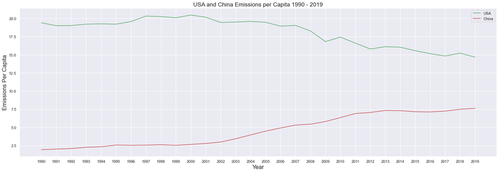

```python
usa_data = industrialization_data.loc[industrialization_data['country_name'] == 'United States']
china_data = industrialization_data.loc[industrialization_data['country_name'] == 'China']

plt.plot(usa_data['year'], usa_data['emissions_per_cap'], color='g', label='USA')
plt.plot(china_data['year'], china_data['emissions_per_cap'], color='r', label='China')

plt.xlabel('Year', fontsize = 17)
plt.ylabel('Emissions Per Capita', fontsize = 17)
plt.title('USA and China Emissions per Capita 1990 - 2019', fontsize = 17)
plt.legend();
```

So there is a lot of really interesting information here. First, we see that the US has a very high carbon emissions rate, which peaks around the year 2000 and starts to decline rather sharply. Note though that in 2019 at its lowest point in this dataset it was at 15 metric tons per capita which is still a lot. China, meanwhile, begins a sharp increase around 2000 as the country began to rapidly industrialize. They did more or less level off in the early 2010s, and while they still emit a ton of carbon, it's not that easy to just move an enormous industrial economy and an energy grid that caters to over a billion people off of fossil fuels. They are beginning to invest heavily in renewable technology like solar power. It's worth noting that their peak is about half of where the US ended up after their decline.

I had thought China's emissions would have pulled East Asia's grouping up significantly among the rest, similar to how their population density pulled the region up, but it turns out that their emissions are just nowhere near what the US's are (and Canada is also a fairly high emitter given its small population), while China has a large number of megacities (cities with a population over 10 million) and quite a few that are approaching that mark, so they are simply contributing more to the population density factor.

Another effective way to look at the proportions is with an area chart. This drives it home in a way that a line chart doesn't.

NOTE: I got help for the main line of code for this, which I use in similar ways throughout this project (when you learn a new thing it's great to use it a lot), from Myles the Mentor after struggling for hours: https://knowledge.udacity.com/questions/890672. I did not know about the unstack function until he told me about it (I'm the author of that post). This is cited at the bottom as well.

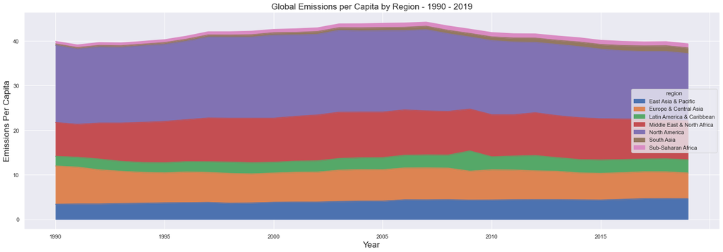

```python
emissions = industrialization_data[['region', 'year', 'emissions_per_cap']]
emissions.set_index('year', inplace = True)
emissions = industrialization_data.groupby(['year', 'region'])['emissions_per_cap'].mean().unstack('region').plot(kind = 'area')
plt.xlabel('Year', fontsize = 17)
plt.ylabel('Emissions Per Capita', fontsize = 17)
plt.title('Global Emissions per Capita by Region - 1990 - 2019', fontsize = 17)
plt.show()
```

Next I want to do some pair plots for various variables. This is for a sample of the whole dataset - after this I will look at some specific regions of interest.

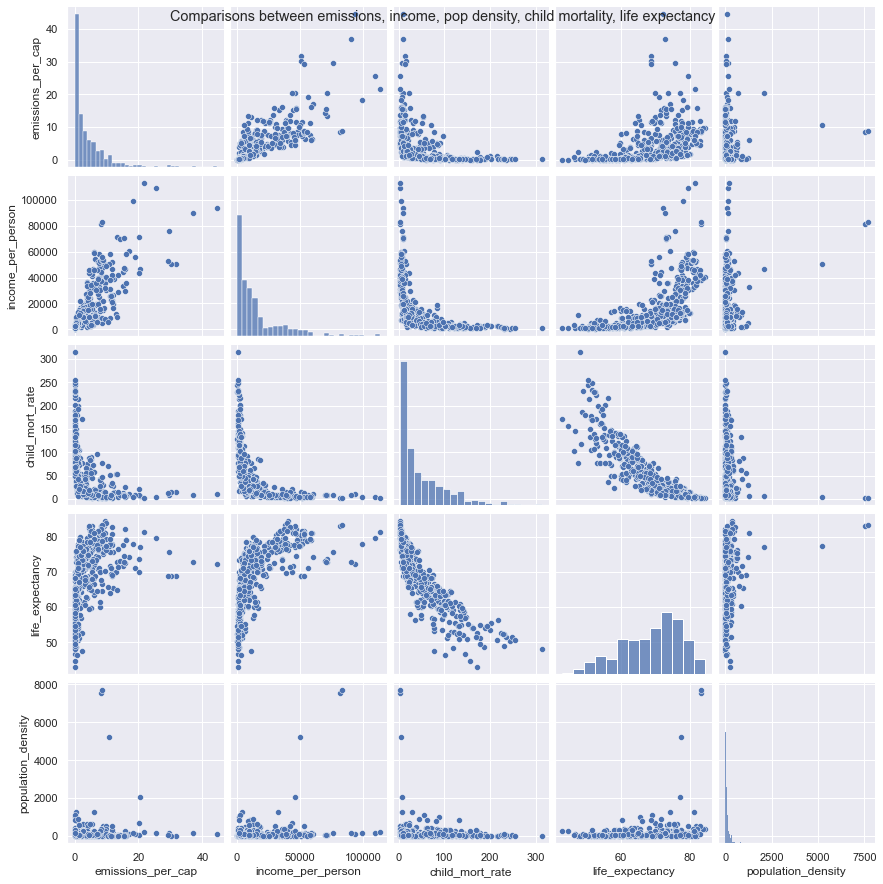

```python
industrial_sample = industrialization_data.sample(n = 500, replace = False)
pairs = sns.pairplot(data = industrial_sample, vars= ['emissions_per_cap', 'income_per_person', 'child_mort_rate', 'life_expectancy', 'population_density'])
pairs.fig.suptitle('Comparisons between emissions, income, pop density, child mortality, life expectancy');
```

There's a lot of good stuff here. Let's go in order from bottom up on the Y axis.

1. Population density - Some obvious ones: the lower the density, the lower the emissions, lower income in areas of lower population density. A bit of a tendency towards lower child mortality as the density increases, but not significant. Similarly a bit of an increase in life expectancy as density increases, but I think both of these could be attributed to easier access to medical care and other resources.
2. Life expectancy - an exponential positive correlation with both emissions and income, but with emissions the majority is towards the lower emissions end. Increased emissions indicate industrial development which will influence these other factors that positively influence life expectancy, but the majority of emissions is simply within a certain bracket. The strong negative correlation between child mortality and life expectancy is obvious.
3. Child mortality - With emissions we can see at a low emissions rate the data spans the range of child mortality levels, but in general there is a slight clumping towards very low emissions/low child mortality, which is very interesting. I would have expected the opposite, to be honest.
4. Income - a somewhat weak but distinct positive correlation with emissions, which makes sense, and kind of a range on life expectancy.
5. Emissions - the last one that hasn't been mentioned is the exponential relationship to life expectancy, which also makes sense when we consider that as countries develop, life expectancy will go up for a variety of reasons.

```python
# function for paired bar charts to reduce repetitive code

def pairbar(plotdata, x_label, y_label, plot_title):
    plotdata.mean().unstack('year').plot(kind = 'bar')
    plt.ylabel(y_label, fontsize = 17)
    plt.xlabel(x_label, fontsize = 17)
    plt.xticks(rotation = 45)
    plt.title(plot_title, fontsize = 17)
    plt.show()
```

```python
#paired bar chart for emissions, life expectancy, income by region for 1990 - 2019
year_subset = industrialization_data.loc[(industrialization_data['year'] == '1990')| (industrialization_data['year'] == '2019')]
emissions_subset = year_subset[['region', 'year', 'emissions_per_cap']]
emissions_bar = emissions_subset.groupby(['year', 'region'])['emissions_per_cap']
```

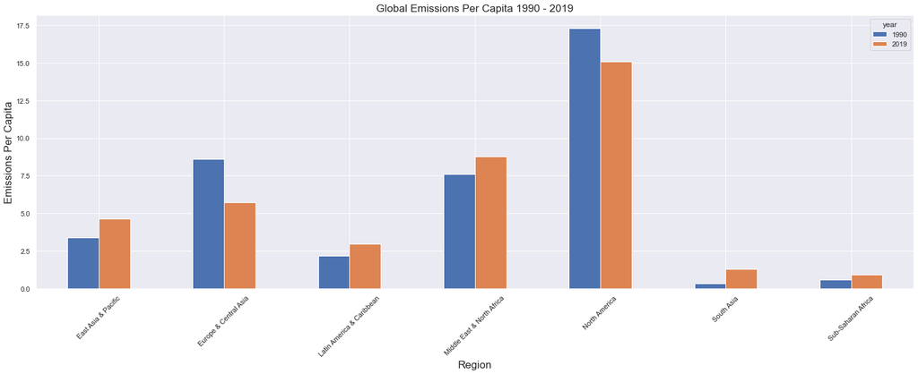

```python
pairbar(emissions_bar, 'Region', 'Emissions Per Capita', 'Global Emissions Per Capita 1990 - 2019')
```

Here we can see that Europe and North America have pretty substantial decreases in emissions over these 30 years (I guess not so substsantial when you consider that it's 30 years), Europe having the biggest drop. All other regions have increases, though mostly fairly small. If we look back up at that multi-line plot, we can see that in the case of the Middle East, that increase is actually because they had a substantial rise, a peak, and then a decline that, at the end point of this dataset, was still slightly above where they were at the beginning of the dataset. So I think in this case the line chart tells the story in a more complete way, even if this isolates the numeric differences in starker terms.

Next let's do one for income. A reminder that this income data represents GDP per capita, not average family income. As I've mentioned, increases in emissions often point to economic development of a society (though not necessarily uniformly throughout that society) which generally will involve an average increase in income and employment opportunities. However we also have seen concerted efforts among more developed countries (Europe, North America) to decrease emissions as they're able, which in context is actually another marker of significant development.

```python
#paired bar chart for income by region for 1990 - 2019
income_subset = year_subset[['region','year', 'income_per_person']]
income_bar = income_subset.groupby(['year', 'region'])['income_per_person']
```

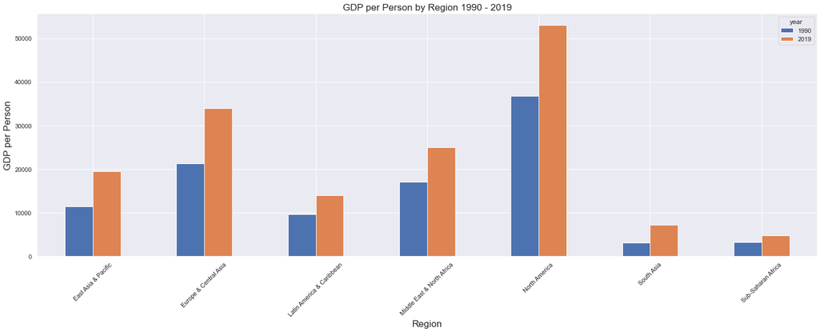

```python
pairbar(income_bar, 'Region', 'GDP per Person', 'GDP per Person by Region 1990 - 2019')
```

These are really huge increases in East Asia, Europe, and North America. As I mentioned above, the development status of North America and Europe, which we can see in these income increases, has allowed those regions to begin to decrease emissions. In the rest of these regions, large parts of which are still developing, or have recently made enormous strides (i.e. China, India), we don't see a decrease in emissions but we do see somewhat substantial increases in income, which lets us pinpoint them at a certain point, albeit somewhat vaguely, in the development trajectory.

```python
#paired bar chart for life expectancy by region for 1990 - 2019
life_subset = year_subset[['country_name', 'region', 'year', 'life_expectancy']]
life_bar = life_subset.groupby(['year', 'region'])['life_expectancy']
```

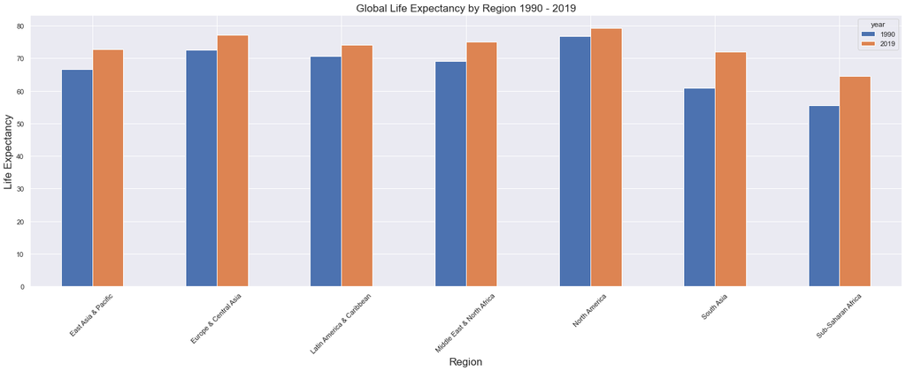

```python
pairbar(life_bar, 'Region', 'Life Expectancy', 'Global Life Expectancy by Region 1990 - 2019')
```

This is encouraging! We see life expectancy go up across the board in all regions, most starkly in SS Africa and South Asia. There are many causes for this that can be tied to economic and social development, including increased income, increased access to and quality of health care, etc. Now I just want to look at the child mortality rates, because as we know, that can affect the life expectancy statistics, and the univariate bar chart from the 1990 data was pretty bleak.

```python
#paired bar chart for child mortality by region 1990 - 2019
mort_subset = year_subset[['region', 'year', 'child_mort_rate']]
mort_bar = mort_subset.groupby(['year', 'region'])['child_mort_rate']
```

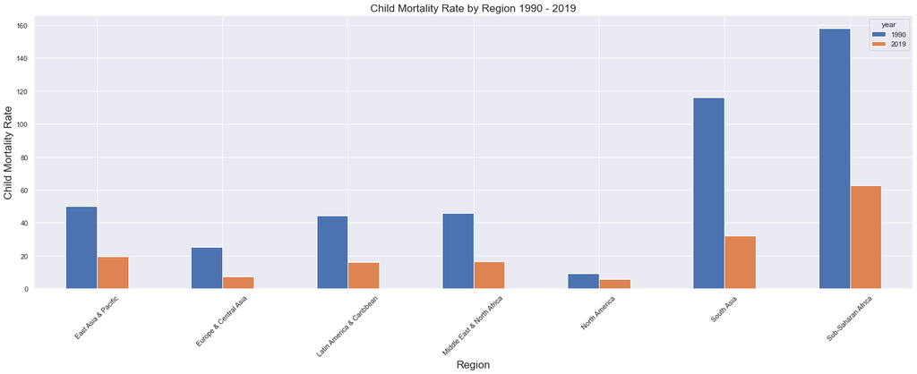

```python
pairbar(mort_bar, 'Region', 'Child Mortality Rate', 'Child Mortality Rate by Region 1990 - 2019')
```

This is actually amazing. The drops in child mortality in South Asia and SS Africa, are literally stunning. I'm stunned. There's a very minor decrease in North America because that rate was already quite low. For the rest of the world this is really wonderful to see.

Now I'd like to do some scatterplots to look at some of these variables in comparison, but for specific regions. One is income against life expectancy for East Asia & Pacific, because I think there is some real economic stratification within that region - i.e. wealthy countries like South Korea, Japan, a lot of much poorer, smaller countries, and some in the middle, like China.

```python
# function for scatterplots to reduce repetitive code

def scatterpl(plotdata, xdata, ydata, x_label, y_label, plot_title):
    plt.scatter(data = plotdata, x = xdata, y = ydata)
    plt.ylabel(y_label, fontsize = 17)
    plt.xlabel(x_label, fontsize = 17)
    plt.title(plot_title, fontsize = 17)
    plt.show()
```

```python
east_asia_subset = industrialization_data.loc[industrialization_data['region'] == 'East Asia & Pacific']
```

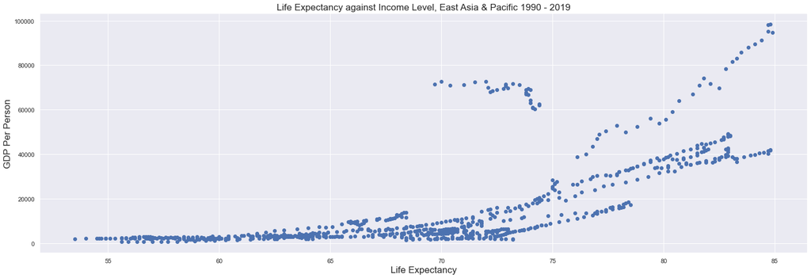

```python
#scatterplot for life expectancy against income level
scatterpl(east_asia_subset, 'life_expectancy', 'income_per_person', 'Life Expectancy', 'GDP Per Person',
          'Life Expectancy against Income Level, East Asia & Pacific 1990 - 2019')
```

Indeed here we can see the kind of stratification I was thinking of, along with some country who is just a blip up there. That is odd because it doesn't even follow the obvious positive correlation the rest of the data does.

```python
#east_asia_life_inc.loc[(east_asia_life_inc['life_expectancy'] < 75) & (east_asia_life_inc['income_per_person'] > 60000)]

# It's Brunei!
```

That weird outlier is Brunei. I don't know enough about Brunei offhand other than that it's an extremely small and rich oil-producing country, to understand why their trajectory would look like that, but it's worth examining later. I'd also like to look at population density against life expectancy. As a lifelong urban resident I know that urban poverty can be wrenching, but at the same time in urban environments you have much, much easier access to critical infrastructure like health care, and other support networks. I'll stick with East Asia because I'm curious if the stratification we can see above is repeated.

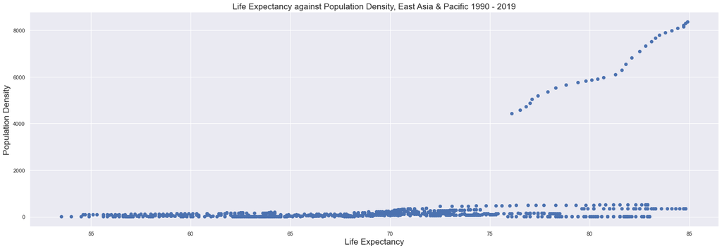

```python
#scatterplot for life expectancy against population density
scatterpl(east_asia_subset, 'life_expectancy', 'population_density', 'Life Expectancy', 'Population Density',
          'Life Expectancy against Population Density, East Asia & Pacific 1990 - 2019')
```

Nope. There is no real relationship there at all. That is honestly really weird to me. I'm curious what that bizarre outlier is though.

```python
#east_asia_life_pop.loc[east_asia_life_pop['population_density'] > 4000]

#it's Singapore!
```

So I checked to see who that outlier is and it's Singapore, which is very densely urban but wealthy and politically stable, so that makes a lot of sense but based on the lack of relationship in general I suspect that that correlation is not strictly causative.

Lastly I want to take a look from another angle at that amazing decrease in child mortality in Sub Saharan Africa. I want to see how that correlates against income/GDP.

```python
# subset and scatterplot for income vs child mortality in SS Africa scatterplot
africa_subset = industrialization_data.loc[industrialization_data['region'] == 'Sub-Saharan Africa']
africa_sample = africa_subset2.sample(n = 300, replace = False)
```

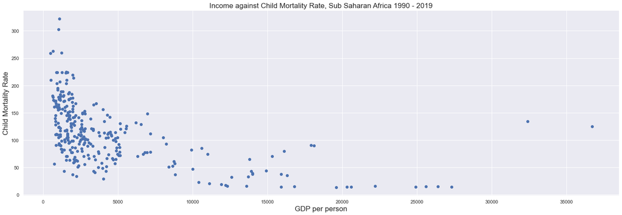

```python
scatterpl(africa_sample, 'income_per_person', 'child_mort_rate', 'GDP per person', 'Child Mortality Rate',
          'Income against Child Mortality Rate, Sub Saharan Africa 1990 - 2019')
```

I had to take a sample because the full data presented a dense and crazy looking plot (there's a lot of countries in Africa). It's interesting that given the insane drop in that bar chart above, there isn't a stronger correlation here. While there is a point at which there seems to be a strong negative correlation towards the beginning of the income scale, it's a bit hard to interpret this. Income has not risen as substantially in the African continent as in other places, so it could be that while there is correlation, the movement is clustered into a small portion of the graph. I flipped the variables to the opposite axes and the result wasn't much more illuminating; it seems to be a weaker correlation than I'd suspected. I suspect that the child mortality rates are attributable to much more than just GDP. Food for thought: The US has one of the worst child mortality rates in the developed world but the highest global GDP.

Now to get a sense of some different details, I'd like to do some violin plots looking at income across different regions.

```python
# function for violin plots

def violinpl(plotdata, xdata, ydata, x_label, y_label, plot_title):
    f, ax = plt.subplots(figsize=(25, 8))
    sns.violinplot(x=xdata, y=ydata, hue='year', data=plotdata)

    f.suptitle(plot_title, fontsize=17)
    ax.set_xlabel(x_label, fontsize = 17)
    ax.set_ylabel(y_label, fontsize = 17)
    #plt.legend(bbox_to_anchor=(1.05, 1), loc='upper left')
```

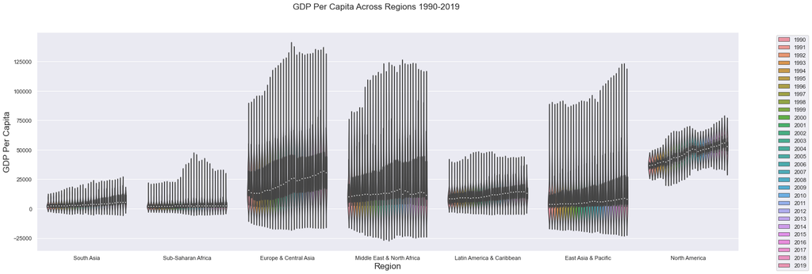

```python
income_subset = industrialization_data[['region', 'year', 'income_per_person']]
violinpl(income_subset, 'region', 'income_per_person', 'Region', 'GDP Per Capita', 'GDP Per Capita Across Regions 1990-2019')
plt.legend(bbox_to_anchor=(1.05, 1), loc='upper left')
```

This plot directly above was actually a mistake - I was trying to make the one right below this, but forgot to subset the data into 1990 and 2019 and ended up with this. I wrote the function afterwards and used the data without the year subset in order to keep this plot because it's awesome. This is really cool you can see how the overall distribution changes in terms of min and max, but you can also see the movement of the quartiles clearly, in each region over 30 years. Like for example while the max income goes up dramatically in sub-saharan Africa (and comes down!), the median stays about the same and there's no real movement in the first or third quartile. Meanwhile in the Middle East, the median actually drops quite a bit and the third quartile and upper bounds increase enormously. In North America, all of it increases steadily but towards the end we see a drop in the median and an expansion of both upper and lower bounds.

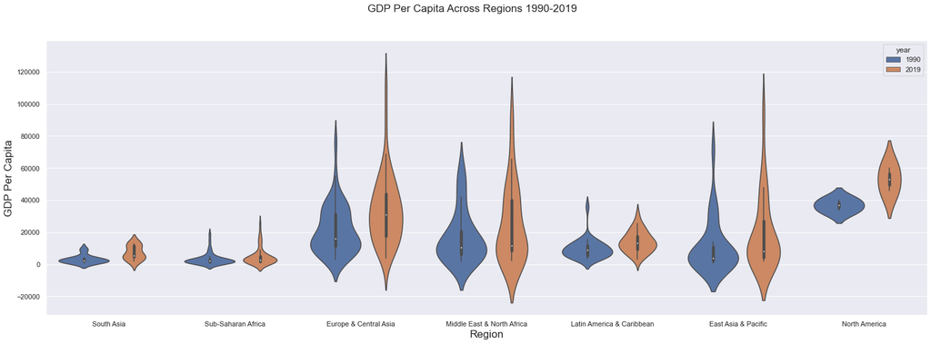

```python
income_subset2 = income_subset.loc[(income_subset['year'] == '1990') |(income_subset['year'] == '2019') ]

violinpl(income_subset2, 'region', 'income_per_person', 'Region', 'GDP Per Capita', 'GDP Per Capita Across Regions 1990-2019')
```

### Talk about some of the relationships you observed in this part of the investigation. How did the feature(s) of interest vary with other features in the dataset?

I was really surprised at what seemed to be a lack of correlation between income and child mortality rates in SS Africa, but this income data represents the GDP per person, not average family income, so that could have something to do with it. Based on the violin plots, it was really evident that while GDP has gone up, wealth inequality has also increased significantly. We did see substantial decreases in child mortality, but it's fair to say that that is attributable to more than just GDP. It was also really surprising that there was such a weak correlation between GDP/income and child mortality. I don't actually know what to make of that, it sort of defies common sense. If I had more time I would probably like to run some multiple regression models to see more about how these variables fit together.

The rest of the data was pretty predictable (income up, life expectancy up, child mortality down etc) but the degree of some of these changes was more remarkable than the changes themselves.

## Multivariate Exploration

I went a bit nuts in the previous section so this will be more brief. Here I wanted to look at some comparisons between regions that had either had some noteworthy changes, or are in very difference places in terms of their emissions goals. So I chose the Middle East, which is a huge emitter as we saw before, Europe, which has been declining their emissions, and East Asia & Pacific, which had some interesting economic stratification. For a third variable I chose life expectancy to be reflected in size.

```python
emissions_sample = industrialization_data[['region', 'income_per_person', 'emissions_per_cap', 'life_expectancy']]
plot1 = emissions_sample.loc[(emissions_sample['region'] == 'Middle East & North Africa') | (emissions_sample['region'] == 'East Asia & Pacific') | (emissions_sample['region'] == 'Europe & Central Asia')]

#plot without size parameter - do not delete

#f = sns.FacetGrid(data = plot1, hue = 'region', height = 9)
#f = f.map(sns.regplot, 'income_per_person', 'emissions_per_cap', fit_reg = True)
#f.add_legend()
#plt.xlabel('GDP Per Capita')
#plt.ylabel('Emissions Per Capita');
```

```python
#function for multivariate scatterplots

def fancyscatter(plotdata, xdata, ydata, sdata, x_label, y_label, plot_title):
    g = sns.FacetGrid(data=plotdata, hue= 'region', height = 10)
    g.map_dataframe(sns.regplot, xdata, ydata, scatter=False)
    g.map_dataframe(sns.scatterplot, xdata, ydata, size= sdata, marker='o')
    g.add_legend()
    plt.title(plot_title)
    plt.xlabel(x_label)
    plt.ylabel(y_label);
```

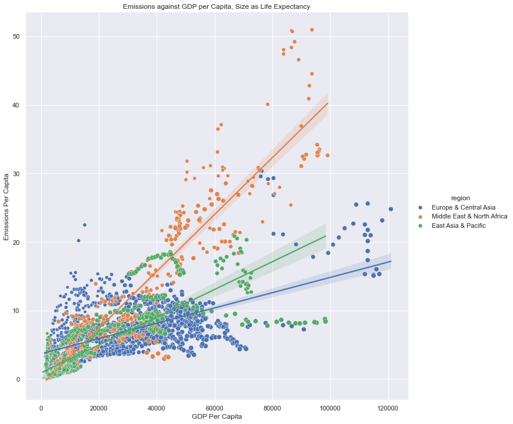

```python
fancyscatter(plot1, 'income_per_person', 'emissions_per_cap', 'life_expectancy', 'GDP Per Capita', 'Emissions Per Capita','Emissions against GDP per Capita, Size as Life Expectancy')
```

There isn't a lot of variation in life expectancy but we do see a trend from lower life expectancy along the low end of GDP, to a higher life expectancy on the high end. The trajectory of the Middle East is very clear, positively correlated with increases in both GDP and emissions. Europe is bunched down with low to middle/high income with some outliers on the X axis, and low/moderate emissions. East Asia & Pacific has some different groupings resembling what we saw earlier. With some exceptions in the Middle East, we don't really see any low life expectancies at higher GDP levels, and all the life expectancies at low/moderate emissions levels and medium/high income levels are high.

Finally I'd like to see the interactions between emissions rates, GDP, and population density.

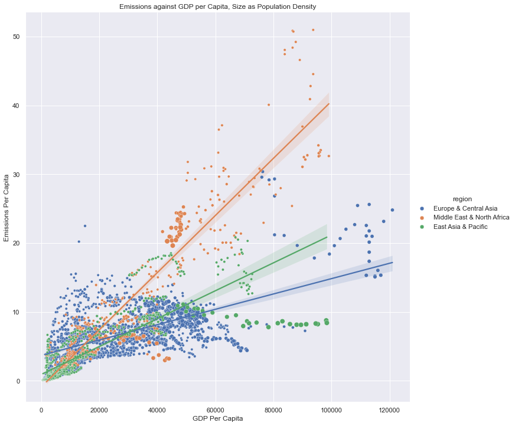

```python
density_sample = industrialization_data[['region', 'population_density', 'emissions_per_cap', 'income_per_person']]
plot2 = density_sample.loc[(density_sample['region'] == 'Middle East & North Africa') | (density_sample['region'] == 'East Asia & Pacific') | (density_sample['region'] == 'Europe & Central Asia')]

fancyscatter(plot2, 'income_per_person', 'emissions_per_cap', 'population_density', 'GDP Per Capita', 'Emissions Per Capita','Emissions against GDP per Capita, Size as Population Density')
```

Let's take this same basic setup and use child mortality as a third variable with color instead of size. The plot I did in the previous section for child mortality was pretty odd and I'd like to see how it may interact as a third variable.

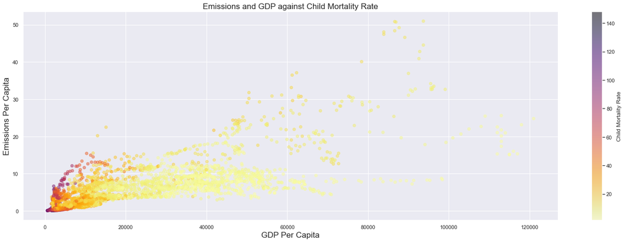

```python
mort_sample = industrialization_data[['region', 'emissions_per_cap', 'income_per_person', 'child_mort_rate']]
plot3 = mort_sample.loc[(mort_sample['region'] == 'Middle East & North Africa') | (mort_sample['region'] == 'East Asia & Pacific') | (mort_sample['region'] == 'Europe & Central Asia')]

plt.scatter(data = plot3, x='income_per_person', y='emissions_per_cap', c='child_mort_rate', cmap = 'inferno_r', alpha = 0.5)
plt.colorbar(label = 'Child Mortality Rate')
plt.title('Emissions and GDP against Child Mortality Rate', fontsize = 17)
plt.xlabel('GDP Per Capita', fontsize = 17)
plt.ylabel('Emissions Per Capita', fontsize = 17);
```

So indeed we can see that high levels of child mortality are clustered around low GDP and low emissions, and decreases as we expand out in both directions. That dark band moving up around the top of the cluster corresponds with the lower income European (or Central Asian) countries that we saw with a low life expectancy in the above plot. This makes a lot more sense to me as a third variable than it did as part of a bivariate plot.

### Were there any interesting or surprising interactions between features?

The above mentioned plot with population density was interesting, but also the third plot showing how child mortality fits into the larger picture. That was another variable that didn't make much sense on its own but as a third variable it was a lot clearer.

## Conclusions

This was a pretty interesting exploration for me as someone with an interest in this topic. Just a reminder, I looked at child mortality rate, life expectancy, GDP per capita, CO2 emissions rate, and population density, for various regions and countries, between the years of 1990 and 2019. A lot of this confirmed general knowledge like that the US/Canada and Europe are reducing carbon emissions but most of the developing world is increasing in emissions due to the nature of development as we currently know it. We also saw a general increase in life expectancy and decrease in child mortality, which is also common knowledge.

It was also interesting to me to see a couple of variables that didn't really make sense in a bivariate setting (population density, child mortality) come to life as third variables in a multivariate setting. I really would like to do some regression analyses at a later time to get more information about how these variables all interact, but I will leave that for another time.

## References/Sources

Datasets (Please note that due to Gapminder's web design they do not have specific URLs for each dataset, but all can be found in their menu):

1. CO2 Emission Around The World: https://www.kaggle.com/datasets/koustavghosh149/co2-emission-around-the-world . Author Koustav Ghosh via World Bank
2. Child Mortality (0-5 Year Olds Dying Per 1000 Born): https://www.gapminder.org/data/
3. Income Per Person (Inflation-Adjusted): https://www.gapminder.org/data/
4. Life Expectancy (Years): https://www.gapminder.org/data/
5. Population Density Per Square KM: https://www.gapminder.org/data/

Code assistance:

1. Final code for area plot adapted from help from Udacity mentor: https://knowledge.udacity.com/questions/890672

Other resources:

1. Kouyakhi, N. 2022. CO2 emissions in the Middle East. Science Direct. https://www.sciencedirect.com/science/article/abs/pii/S0048969722042802?via%3Dihub
2. United Nations, 2011. An assessment of the economic impact of climate change on the Energy Sector in Trinidad and Tobago. United Nations/CEPAL https://www.cepal.org/en/publications/38584-assessment-economic-impact-climate-change-energy-sector-trinidad-and-tobago#:~:text=Almost%2090%25%20of%20these%20CO2,Change%20and%20the%20Kyoto%20Protocol.